# Possible to-do's and discussion points:

Let's see the distribution throught the genes.

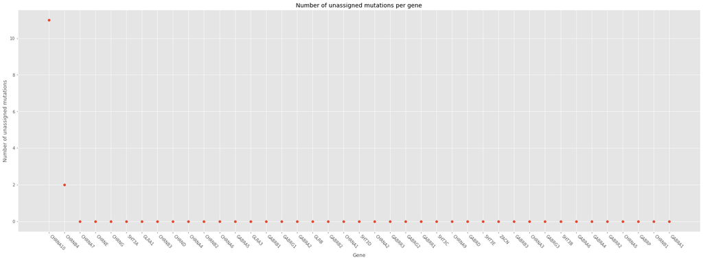

```python
_values["AA Unreferenced"] = _values.apply(lambda x: -sum(missense["AA Referenced"][(missense["AA Referenced"] == -1) & (missense["Gene"] == x["Gene"])]), axis=1)
_values.sort_values(by="AA Unreferenced", ascending=False, inplace=True, ignore_index=True)

pyplot.scatter(_values["Gene"], _values["AA Unreferenced"])
pyplot.xticks(rotation=-45, horizontalalignment="left")
pyplot.xlabel("Gene")
pyplot.ylabel("Number of unassigned mutations")
pyplot.title("Number of unassigned mutations per gene")
pyplot.show()
```

Let's see how this translates into the proportion of the individual gene mutations that are unasigned.

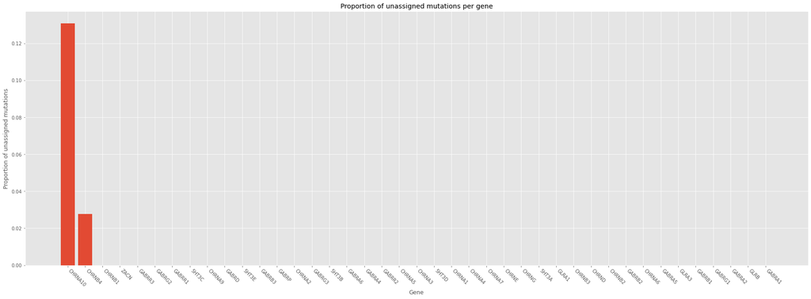

```python
_values["AA Unreferenced"] = _values.apply(lambda x: -sum(missense["AA Referenced"][(missense["AA Referenced"] == -1) & (missense["Gene"] == x["Gene"])]) / sum(missense["Gene"] == x["Gene"]), axis=1)
_values.sort_values(by="AA Unreferenced", ascending=False, inplace=True, ignore_index=True)

pyplot.bar(_values["Gene"], _values["AA Unreferenced"])
pyplot.xticks(rotation=-45, horizontalalignment="left")
pyplot.xlabel("Gene")
pyplot.ylabel("Proportion of unassigned mutations")
pyplot.title("Proportion of unassigned mutations per gene")
pyplot.show()
```

**Note:**

- CHRNA10: has an extra protein coding transcript, which cannot be reliably áligned to the main transcript, so we cannot add it.
- CHRNB4: we already aligned all the transcript we could
- very short sequences (<100 AA) were automatically excluded

For now we check where we find the variants in the reference sequence. There seem to be several hot spots. Note that the parts without signal don't necessarily mean a spot that is mutation-free, but might be a part of the protein that is tolerating the mutations better.

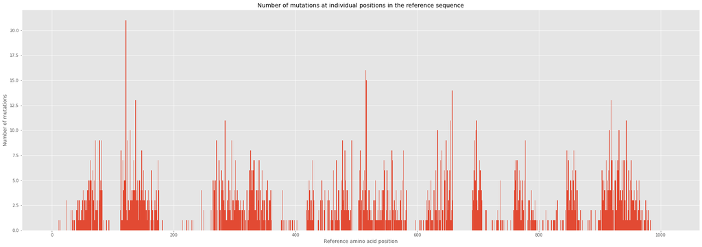

```python
found_missense = missense[missense["AA Referenced"] != -1]
pyplot.hist(found_missense["AA Referenced"], bins=[x for x in range(1, len(alignment[0]))])
pyplot.xlabel("Reference amino acid position")
pyplot.ylabel("Number of mutations")
pyplot.title("Number of mutations at individual positions in the reference sequence")
pyplot.show()
```

Just in case we will also take only one mutation per amino acid, so we can see where multiple genes get mutated.

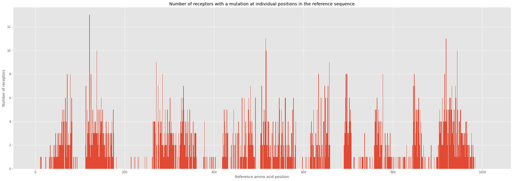

```python
_unique_aas = []
for gene in found_missense["Gene"].unique():
    _unique_aas.extend(found_missense["AA Referenced"][found_missense["Gene"] == gene].unique())
pyplot.hist(_unique_aas, bins=[x for x in range(1, len(alignment[0]))])
pyplot.xlabel("Reference amino acid position")
pyplot.ylabel("Number of receptors")
pyplot.title("Number of receptors with a mutation at individual positions in the reference sequence")
pyplot.show()
```

## Mapping to structural elements

We have a list of the amino acids involved in the structural elements written in a CSV file. We load them in, transform them to the reference numbering and use them as a reference to annotate the table of mutations.

```python
structural_elements = pandas.read_csv("Structural_elements.csv")
structural_elements
```

|  | Gene | AA Name | AA Number | BS |
| --- | --- | --- | --- | --- |
| 0 | GABRB2 | S | 253 | uTMD_principal_extended |
| 1 | GABRB2 | I | 256 | uTMD_principal_extended |
| 2 | GABRB2 | T | 281 | uTMD_principal_extended |
| 3 | GABRB2 | V | 282 | uTMD_principal_extended |
| 4 | GABRB2 | L | 283 | uTMD_principal_extended |
| ... | ... | ... | ... | ... |
| 444 | GABRA1 | S | 417 | ICD |
| 445 | GABRA1 | K | 418 | ICD |
| 446 | GABRA1 | I | 419 | ICD |
| 447 | GABRA1 | D | 420 | ICD |
| 448 | GABRA1 | R | 421 | ICD |

449 rows × 4 columns

```python
structural_elements["AA Referenced"] = structural_elements.apply(lambda x: ali_class.convert_to_reference(x["Gene"], x["AA Name"], x["AA Number"]) , axis=1)
structural_elements
```

|  | Gene | AA Name | AA Number | BS | AA Referenced |
| --- | --- | --- | --- | --- | --- |
| 0 | GABRB2 | S | 253 | uTMD_principal_extended | 530 |
| 1 | GABRB2 | I | 256 | uTMD_principal_extended | 533 |
| 2 | GABRB2 | T | 281 | uTMD_principal_extended | 559 |
| 3 | GABRB2 | V | 282 | uTMD_principal_extended | 560 |
| 4 | GABRB2 | L | 283 | uTMD_principal_extended | 561 |
| ... | ... | ... | ... | ... | ... |
| 444 | GABRA1 | S | 417 | ICD | 939 |
| 445 | GABRA1 | K | 418 | ICD | 940 |
| 446 | GABRA1 | I | 419 | ICD | 941 |
| 447 | GABRA1 | D | 420 | ICD | 942 |
| 448 | GABRA1 | R | 421 | ICD | 943 |

449 rows × 5 columns

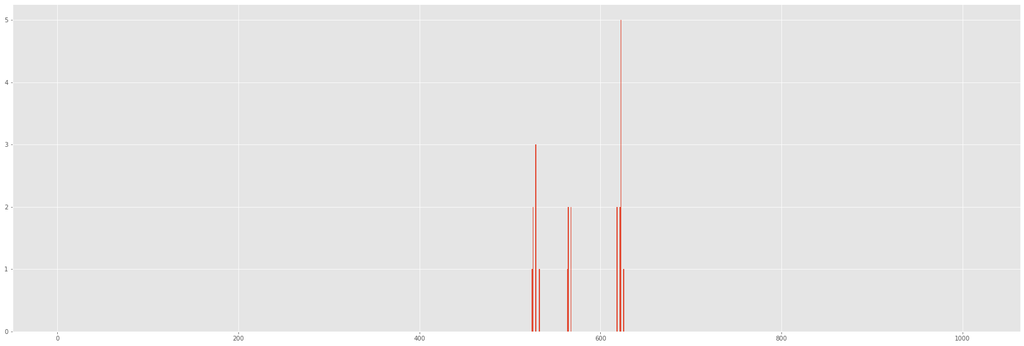

```python
close_only = missense[missense["AA Referenced"].isin(structural_elements["AA Referenced"][structural_elements["BS"].isin(["uTMD_principal_close", "uTMD_complementary_close"])])]

pyplot.hist(close_only["AA Referenced"], bins=[x for x in range(1, len(alignment[0]))])
pyplot.show()
```

```python
missense_annotated = pandas.merge(missense, structural_elements[["AA Referenced", "BS"]][~structural_elements["BS"].isin(("ECD", "TM1", "TM2", "TM3", "TM4", "ICD"))], how="left", on="AA Referenced")
```

```python
missense_annotated = missense_annotated[~missense_annotated["BS"].isna()]
missense_annotated
```

|  | level_0 | index | Chromosome | Position | rsIDs | Reference | Alternate | Source | Filters - exomes | Filters - genomes | ... | Allele Count European (non-Finnish) | Allele Number European (non-Finnish) | Homozygote Count European (non-Finnish) | Hemizygote Count European (non-Finnish) | Gene | Transcript | AA Number | AA Relative | AA Referenced | BS |
| --- | --- | --- | --- | --- | --- | --- | --- | --- | --- | --- | --- | --- | --- | --- | --- | --- | --- | --- | --- | --- | --- |
| 41 | 986 | 994 | 6 | 89264498.0 | rs147948500 | A | T | gnomAD Genomes | NaN | PASS | ... | 0.0 | 67988.0 | 0.0 | 0.0 | GABRR2 | NaN | 334 | 0.718280 | 627.0 | uTMD_principal_extended |
| 42 | 995 | 1003 | 6 | 89264537.0 | rs2228644 | C | T | gnomAD Genomes | NaN | PASS | ... | 8.0 | 68034.0 | 0.0 | 0.0 | GABRR2 | NaN | 321 | 0.690323 | 582.0 | uTMD_principal_extended |
| 45 | 1005 | 1013 | 6 | 89264567.0 | rs759038477 | C | T | gnomAD Genomes | NaN | PASS | ... | 0.0 | 68036.0 | 0.0 | 0.0 | GABRR2 | NaN | 311 | 0.668817 | 570.0 | uTMD_principal_extended |
| 46 | 1011 | 1019 | 6 | 89264572.0 | rs530768090 | G | C | gnomAD Genomes | NaN | PASS | ... | 0.0 | 68030.0 | 0.0 | 0.0 | GABRR2 | NaN | 309 | 0.664516 | 568.0 | uTMD_principal_extended |
| 47 | 1012 | 1020 | 6 | 89264578.0 | rs376233796 | A | T | gnomAD Genomes | NaN | PASS | ... | 3.0 | 68030.0 | 0.0 | 0.0 | GABRR2 | NaN | 307 | 0.660215 | 566.0 | uTMD_principal_extended |
| ... | ... | ... | ... | ... | ... | ... | ... | ... | ... | ... | ... | ... | ... | ... | ... | ... | ... | ... | ... | ... | ... |
| 1905 | 25837 | 27642 | 17 | 4900805.0 | rs370019023 | G | C | gnomAD Genomes | NaN | PASS | ... | 3.0 | 68038.0 | 0.0 | 0.0 | CHRNE | ENST00000649488.2 | 302 | 0.612576 | 615.0 | uTMD_principal_extended |
| 1906 | 25839 | 27644 | 17 | 4900809.0 | rs140023380 | C | T | gnomAD Genomes | NaN | PASS | ... | 38.0 | 68042.0 | 0.0 | 0.0 | CHRNE | ENST00000649488.2 | 301 | 0.610548 | 582.0 | uTMD_principal_extended |
| 1951 | 26786 | 28623 | 15 | 32158511.0 | rs142728508 | A | G | gnomAD Genomes | NaN | PASS | ... | 73.0 | 67864.0 | 0.0 | 0.0 | CHRNA7 | ENST00000306901.9 | 233 | 0.464143 | 522.0 | uTMD_complementary_extended |
| 1960 | 26824 | 28710 | 15 | 32168053.0 | rs759840872 | T | C | gnomAD Genomes | NaN | PASS | ... | 3.0 | 68042.0 | 0.0 | 0.0 | CHRNA7 | ENST00000635884.1 | 270 | 0.537849 | 530.0 | uTMD_principal_extended |
| 1961 | 26824 | 28710 | 15 | 32168053.0 | rs759840872 | T | C | gnomAD Genomes | NaN | PASS | ... | 3.0 | 68042.0 | 0.0 | 0.0 | CHRNA7 | ENST00000635884.1 | 270 | 0.537849 | 530.0 | uTMD_complementary_extended |

102 rows × 68 columns

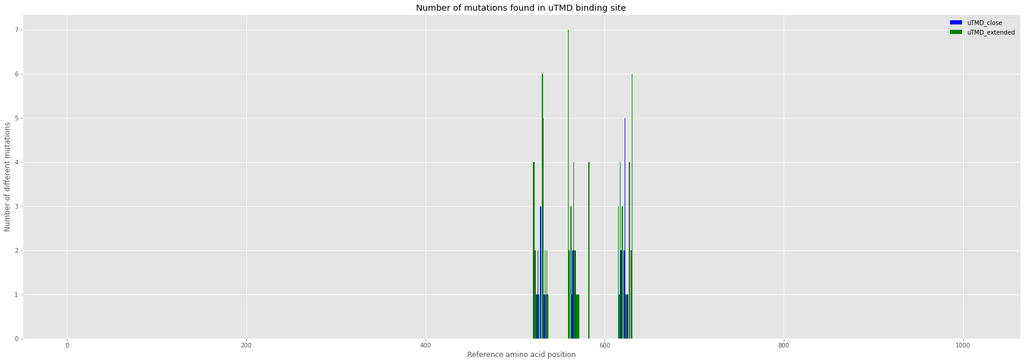

```python
pyplot.hist(missense_annotated["AA Referenced"][missense_annotated["BS"].str.endswith("close")], bins=[x for x in range(1, len(alignment[0]))], color = "blue", label="uTMD_close")
pyplot.hist(missense_annotated["AA Referenced"][missense_annotated["BS"].str.endswith("extended")], bins=[x for x in range(1, len(alignment[0]))], color = "green", label="uTMD_extended")
pyplot.xlabel("Reference amino acid position")
pyplot.ylabel("Number of different mutations")
pyplot.title("Number of mutations found in uTMD binding site")
pyplot.legend()
pyplot.show()
```

```python
missense_annotated["Allele Relative"] = missense_annotated["Allele Count"]/missense_annotated["Allele Number"]
```

```python
missense_annotated.reset_index(inplace=True, drop=True)
```

```python
print(*missense_annotated.duplicated(subset=["Gene", "AA Referenced"]).tolist(), sep="\n")
```

[output not shown]

[output cut: 47 more lines]

[output not shown]

Multiple mutations in a gene can map to the single codon. As such we will aggregate those into a single entry by summing up their frequencies. This is not necessarily completely correct, but in this case we don't have extra data that could help us make a better estimation.

```python
missense_annotated_mini = missense_annotated[["Gene", "AA Referenced", "Allele Relative"]]
missense_annotated_mini = missense_annotated_mini.groupby(["Gene", "AA Referenced"]).sum()
missense_annotated_mini.reset_index(inplace=True)
missense_annotated_mini = missense_annotated_mini.pivot("Gene", "AA Referenced", "Allele Relative")
missense_annotated_mini[missense_annotated_mini.isna()] = 0
```

```python
fig = px.imshow(missense_annotated_mini)
fig.show()
```

[output not shown]

# Extra: Checking H267 and E270 from GABRB3

**Note:** The numbering is without the signal peptide; we add 25 AAs because that is the signal peptide length in GABRB3

```python
aa_referenced = [ali_class.convert_to_reference("GABRB3", "H", 267+25), ali_class.convert_to_reference("GABRB3", "E", 270+25)]
aa_referenced
```

```
[569, 572]
```

```python
subset = missense[missense["AA Referenced"].isin(aa_referenced)]
subset
```

|  | level_0 | index | Chromosome | Position | rsIDs | Reference | Alternate | Source | Filters - exomes | Filters - genomes | ... | Hemizygote Count African/African-American | Allele Count European (non-Finnish) | Allele Number European (non-Finnish) | Homozygote Count European (non-Finnish) | Hemizygote Count European (non-Finnish) | Gene | Transcript | AA Number | AA Relative | AA Referenced |
| --- | --- | --- | --- | --- | --- | --- | --- | --- | --- | --- | --- | --- | --- | --- | --- | --- | --- | --- | --- | --- | --- |
| 567 | 6680 | 7581 | 3 | 97993001.0 | rs749225173 | C | T | gnomAD Genomes | NaN | PASS | ... | 0.0 | 0.0 | 68026.0 | 0.0 | 0.0 | GABRR3 | NaN | 319 | 0.683084 | 572.0 |
| 1135 | 14740 | 15703 | 4 | 157152765.0 | rs750803516 | G | A | gnomAD Genomes | NaN | PASS | ... | 0.0 | 7.0 | 68010.0 | 0.0 | 0.0 | GLRB | ENST00000264428.9 | 318 | 0.639839 | 572.0 |
| 1229 | 16341 | 17305 | 8 | 42732158.0 | rs75384358 | A | G | gnomAD Genomes | NaN | PASS | ... | 0.0 | 0.0 | 68042.0 | 0.0 | 0.0 | CHRNB3 | ENST00000289957.3 | 284 | 0.620087 | 572.0 |
| 1837 | 25161 | 26962 | 11 | 113986680.0 | rs759087911 | A | T | gnomAD Genomes | NaN | PASS | ... | 0.0 | 0.0 | 68014.0 | 0.0 | 0.0 | 5HT3A | NaN | 290 | 0.606695 | 569.0 |

4 rows × 67 columns

```python
(subset["Gene"] + "_" + subset["AA Referenced"].astype(int).astype(str)).values.tolist()
```

```
['GABRR3_572', 'GLRB_572', 'CHRNB3_572', '5HT3A_569']
```

```python
matplotlib.rcParams["figure.figsize"] = (10, 10)
```

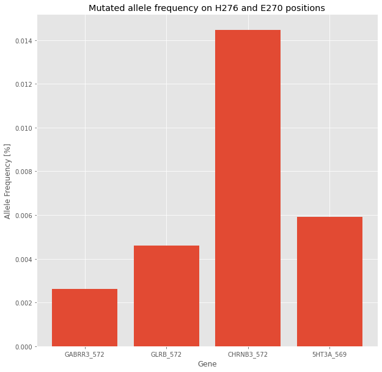

```python
pyplot.bar(subset["Gene"] + "_" + subset["AA Referenced"].astype(int).astype(str), subset["Allele Count"]/subset["Allele Number"]*100)
pyplot.xlabel("Gene")
pyplot.ylabel("Allele Frequency [%]")
pyplot.title("Mutated allele frequency on H276 and E270 positions")
pyplot.show()
```

**NOTE:**

- GABRB3 H267 = 569
- GABRB3 E270 = 572